# Gov 1372 - Groups and Identities

your name here

September 23, 2021

# Marriage and Partisan Polarization

Iyengar and Westwood (2014) use answers to questions about a child marrying an in-party or out-party spouse as one way of characterizing affective partisan polarization. Some authors have questioned if the way this question is framed too coarsely. In particular, [Klar et al. (2018)](https://drive.google.com/file/d/1FOAPqfLQweUFaXtzLGhJT_kkBRwHWkLu/view?usp=sharing) argue that, by making the prospective child-in-law’s partisanship salient, the marriage question may be picking up on respondents dislike of partisanship in general, rather than a dislike of the opposing party.

The in-class survey you took was a partial replication of the Klar et al. (2018) study. We randomized whether you were asked about a prospective child-in-law who “frequently talks about politics,” “rarely talks about politics,” or a person whose frequency of discussing politics was not mentioned. This last, control, condition matches the wording of the question used in Iyengar and Westwood (2014).

**Data Details:**

[output not shown]

Once again, the .Rmd version of this file has code you can use to load the data.

These data are *not* the raw output from the survey you took. In particular, all of the indicator variables are the result of coding decisions and data processing done by the instructors (based on the procedures used in Klar et al. (2018)). For the first few questions, just open up the data and take a look at it (ask us if you need help viewing the data in spreadsheet format in RStudio).

## Question 2

Now let’s take a look at if there are differences in some of the key outcome variables depending on treatment status. Here is an example of how you might make a graph to look at if the rates of unhappiness with a prospective out-party in-law differ depending on the frequency with which they talk about politics.

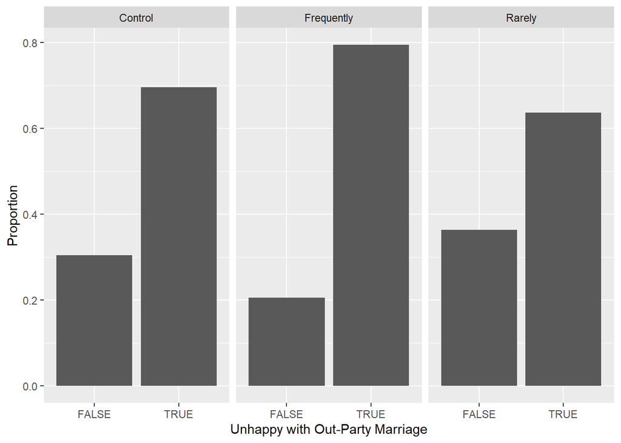

## Question 3

**Comment on what you see in the example graph. Did the treatment affect unhappiness with a prospective out-party member coming into the family?**

## Question 4

**Did the different treatment conditions affect the proportions of people who were affectively polarized? Make a plot and explain what you found.**

[output not shown]

[output cut: 79 more lines]

## Question 5

**Take a quick look at Figure 1 and Figure 2 in [Klar et al. (2018)](https://academic.oup.com/poq/article-abstract/82/2/379/4996003). How do the results from our in-class data compare to their results? What might explain any differences? If there aren’t an notable differences, is there a common pattern across the two datasets that is puzzling? What hypothesis do you have to explain it.**

## Question 6 (Data Science Question)

**We might also be interested in if things looked different for weak vs. strong partisans. Pick one of the two outcome variables you just examined and make a plot that would help us understand if responses within and across treatment groups differ between weak and strong partisans.**

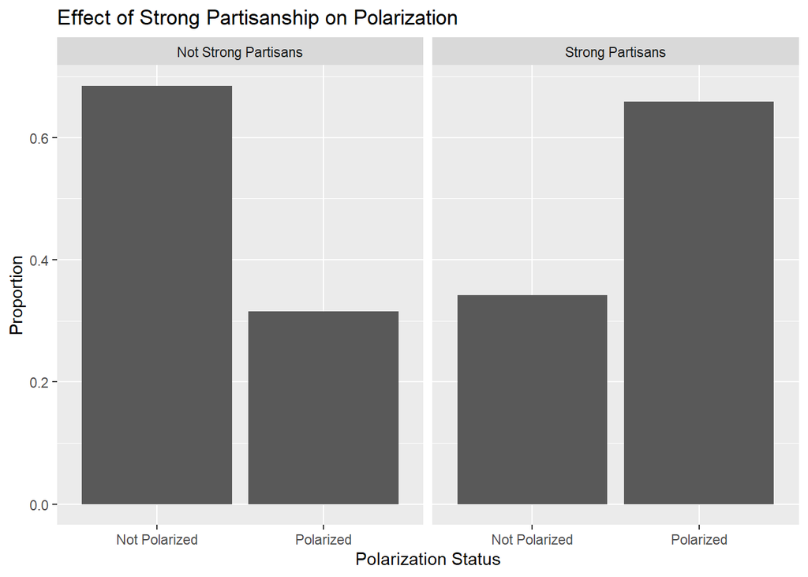

## Question 7

**Are there any other issues you can think of that might confound the utility of the marriage question as a measure of affective polarization? If you have any concerns, how might you design a study to evaluate your hypotheses?**

## Question 8

**Based on the data and your work on this assignment, are there any changes you would make to the Iyengar and Westwood (2014) study or the Klar et al. (2018) study or extensions of the research that you would like to see? (For example, would you alter the wording of any questions, change the experimental protocol, or come to any different conclusions?)**